# Migration Hump: Deconstructing the cross-section

David Benček & Claas Schneiderheinze

23 July 2019

## Summary

The migration hump is a well-known phenomenon among researchers, practitioners as well as politicians and most prominently propagated by Clemens (2014) and Clemens and Postel (2018). We demonstrate that the migration hump is based entirely on cross-sectional data. Causal interpretations of the relationship between income and emigration are thus dependent on very strong assumptions. We suggest that the cross-sectional hump may be due to other country-specific factors. In order to identify the impact of income on emigration, we argue that it is necessary to use time-series analyses of a subset of countries.

## Reproducing Clemens (2014)

First we reproduce the central plot in Clemens (2014) showing the inverted U-shaped relationship between per capita GDP and emigration rates. This is done using the same data sources:

- decadal migration flows are derived from World Bank bilateral migration stocks, expanded by one decade;
- GDP and population numbers are taken from the Penn World Table (version 8).

We follow the approach described by Clemens (2014), estimating nonparametric regressions for each decade and end up with virtually the same representation of the data (left: Clemens (2014); right: our estimation and visualization). The only difference is the estimated regression line for the decade 1970–1980 - perhaps there has been a revision of the World Bank data that reduced estimated migration stocks from high-income countries in 1980. The rest of the fitted lines correspond to the original and reproduce the visible increase of emigration rates up until per capita incomes of about PPP$5000.

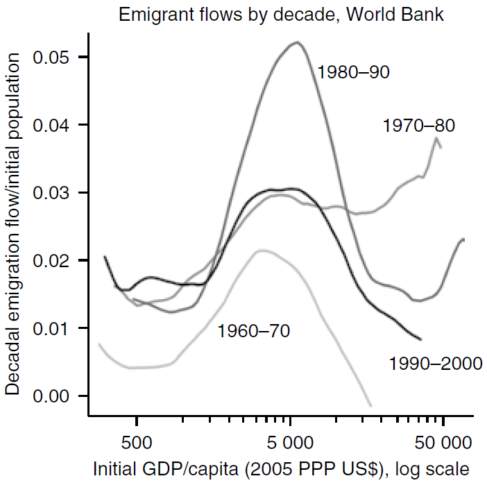

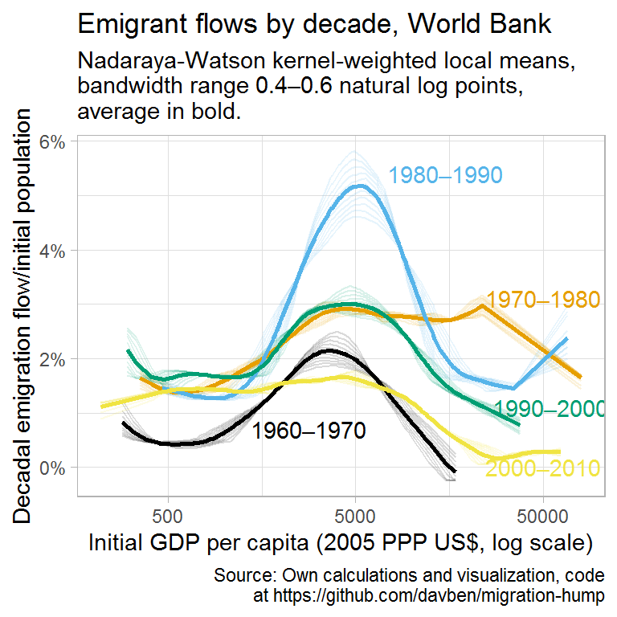

## What may drive this cross-sectional relationship?

While Clemens (2014) makes sure to emphasize that the depicted relationship does not necessarily “demonstrate a transition path that any given country must take”, his theoretical arguments about the mobility transition as well as his portrayal of the cross-sectional analysis as being methodologically superior to time-series approaches strongly imply an advocacy of a causal interpretation. This becomes even clearer in Clemens and Postel (2018).

We argue that the cross-sectional migration hump may be misleading and be partly based on various country-specific attributes. To make things easier to follow, we can first view each decade separately.

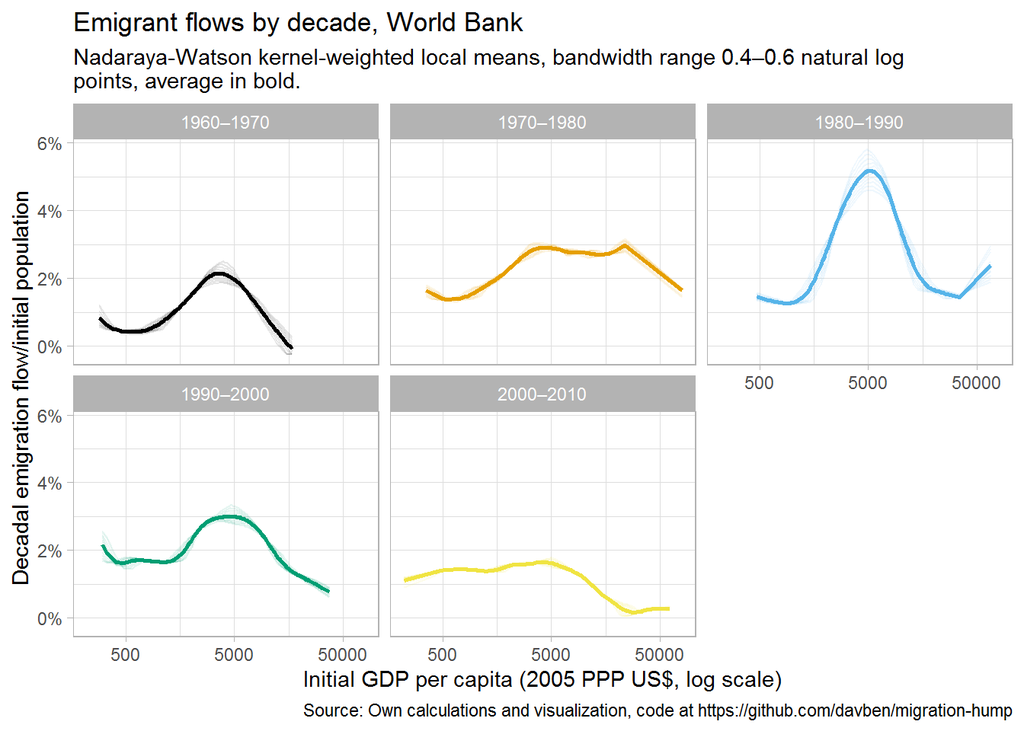

So far, we have only seen the fitted regression line to get an idea of the hump. When we add in the observed data points, the inverted U-shape actually becomes a lot less pronounced and we may start to suspect that it is possibly driven by those few observations with migration rates well above 5 percent.

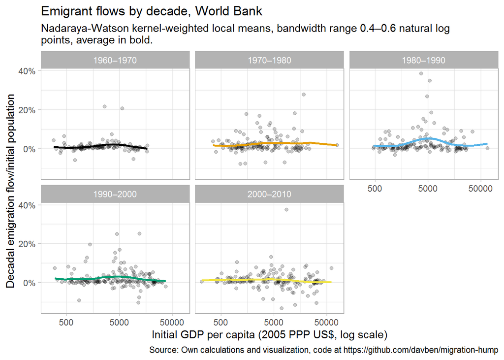

What kind of countries have such high emigration rates in the duration of a single decade? The plot below depicts country size in two ways:

- physical size (measured as the surface area in log km<sup>2</sup>), reflected in the area of the circles;
- population size (measured as a binary variable indicating a population below or above 2.5 million), reflected in the colour of the circles.

Among those countries that drive the inverted U-shape of the fitted line, the vast majority is small in both physical size and population.

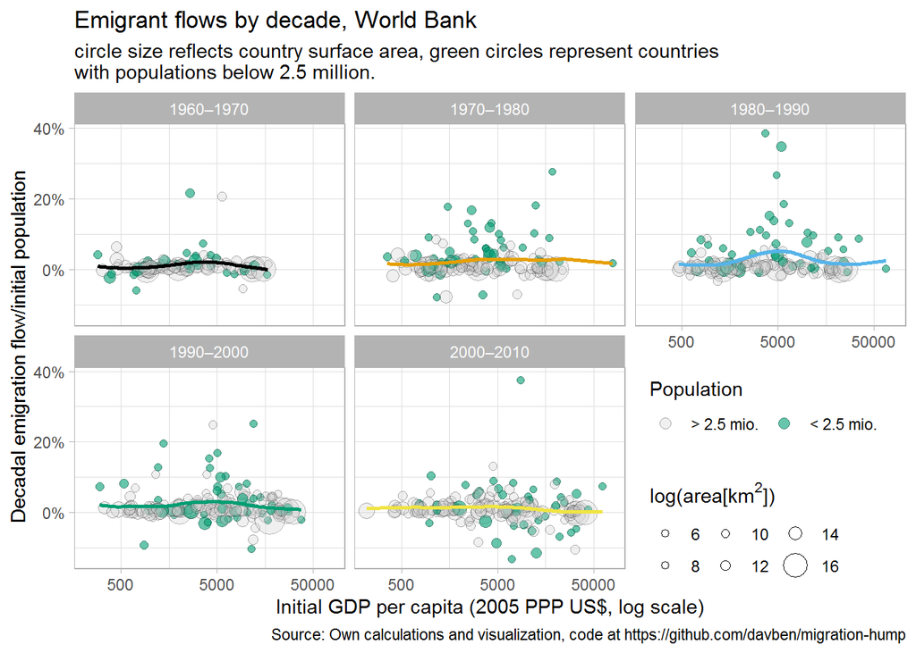

There are multiple reasons why small countries may exhibit higher emigration rates than large ones. For one, countries like St. Kitts & Nevis for example have such a low population that even emigration flows that are small in absolute terms represent a significant percentage of the entire population. Furthermore, it is much easier to leave a country the area of which is small as it is less costly or also physically demanding to reach the nearest border. Accordingly, the outliers in this analysis include countries such as Barbados, Cape Verde, Portugal, Albania, Eswatini and Luxembourg.

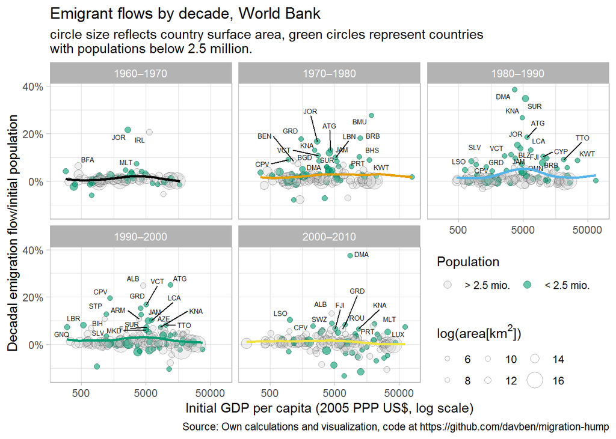

## Our approach to identify the effect of income on emigration

One of the arguments Clemens (2014) makes in favour of a cross-sectional instead of a panel analysis is that the latter would not be able to identify the inverted U-shape: Because time-series data for individual countries is mostly limited to 20 to 30 years of observations, panel studies can only analyze a slice of a potentially century-long development process along the estimated curve.

To mitigate this problem, we split the hypothesized hump into two parts - one with an increasing and one with a decreasing slope. The following figure demonstrates this using a sample split at an income level of 7000 US$ per capita and two separate fitted OLS-regressions for each decade.

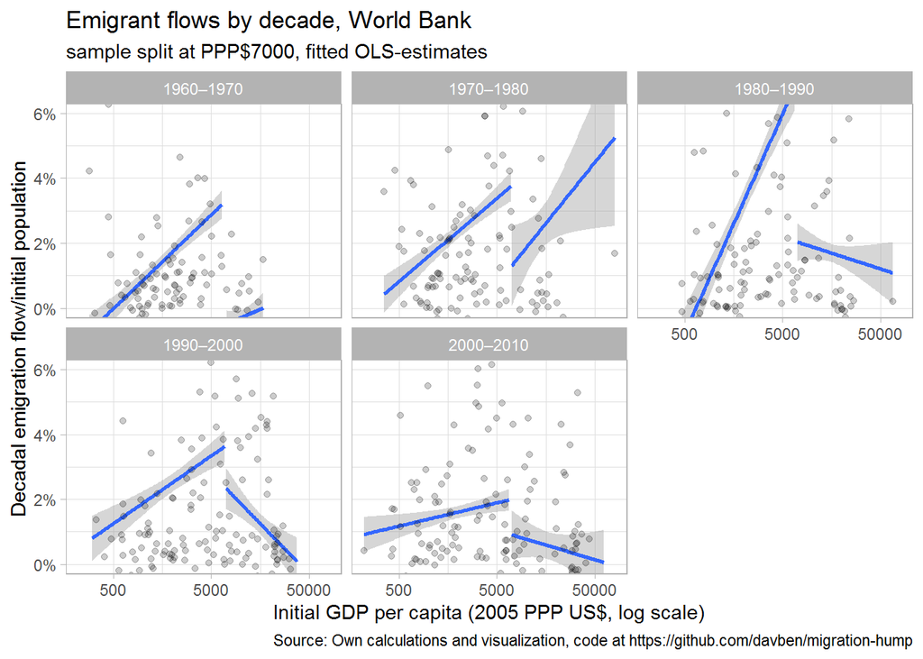

While the right side of the hump is all over the place using a linear model, the left side, i.e. the sample of low-income countries, exhibits a robust positive slope across the decades. In our empirical analysis we therefore focus on a set of countries that has remained on the left-hand side of the supposed peak of the migration hump throughout the observation period. Using panel regressions on this reduced sample we would have to find a robust positive effect of income on emigration rates.

## References

Clemens, Michael A. 2014. “Does Development Reduce Migration?” In *International Handbook on Migration and Economic Development*, edited by Robert E. B. Lucas, 152–85. Cheltenham, UK: Edward Elgar. https://www.elgaronline.com/view/9781782548065.00010.xml.

Clemens, Michael A., and Hannah M. Postel. 2018. “Deterring Emigration with Foreign Aid: An Overview of Evidence from Low-Income Countries.” *Population and Development Review* 44 (4): 667–93. https://doi.org/10.1111/padr.12184.